# Logistic Regression

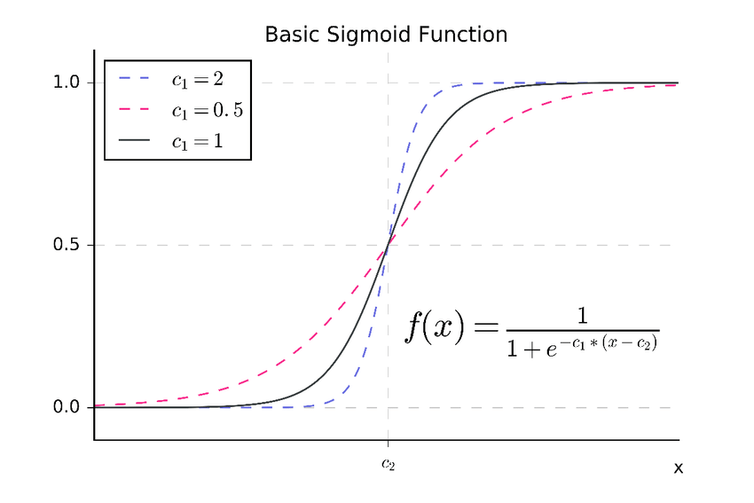

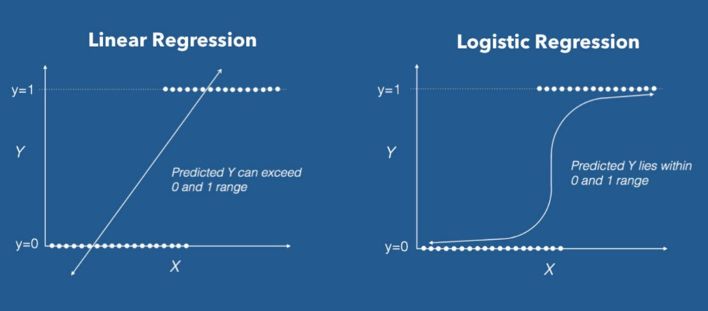

[figure not shown]

- In a Neural Network:

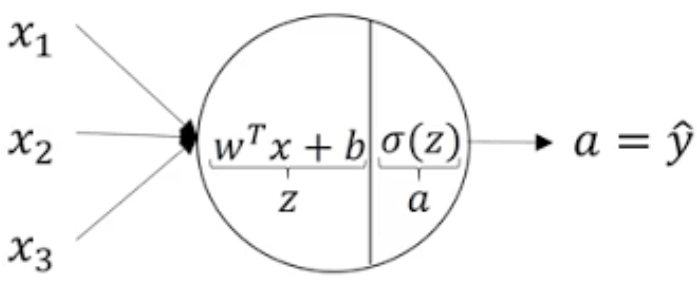

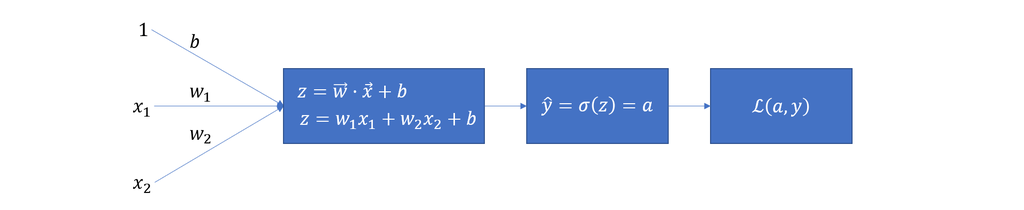

We want:

$y = 1$; $P(y| \textbf{x}) = \hat{y}$.

$y = 0$; $P(y| \textbf{x}) = 1 - \hat{y}$.

Therefore:

$P(y| \textbf{x} ) = \hat{y}^{y} (1 - \hat{y})^{1 - y}$

$\log \left[ P(y| \textbf{x}) \right] = \log \left[ \hat{y}^{y} (1 - \hat{y})^{1 - y} \right]$

$\log \left[ P(y| \textbf{x}) \right] = y \log \hat{y} + (1 - y) \log ( 1 - \hat{y} )$

- We want to MAXIMIZE the probability P.
- Ie., we want to minimize the loss $\mathcal{L}(y,\hat{y})$

$\mathcal{L}(\hat{y}, y) = - \log \left[ P(y| \textbf{x}) \right]$

$\boxed{\mathcal{L}(\hat{y}, y) = - y \log \hat{y} - (1 - y) \log ( 1 - \hat{y} )}$

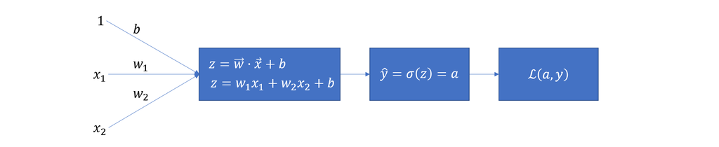

Loss:

$\mathcal{L}(\hat{y}, y) = - y \log \hat{y} - (1 - y) \log ( 1 - \hat{y} )$

$\mathcal{L}(a, y) = - y \log a - (1 - y) \log ( 1 - a )$

$\dfrac{\partial \mathcal{L}(a, y)}{\partial a} = - \dfrac{y}{a} + \dfrac{1-y}{1-a}$

$\dfrac{\partial a(z)}{\partial z} = \dfrac{\partial}{\partial z} \left ( \dfrac{1}{1 + e^{-z}} \right ) = a(1-a)$

$\dfrac{\partial \mathcal{L}(a,y)}{\partial z} = \dfrac{\partial \mathcal{L}(a,y)}{\partial a} \dfrac{\partial a(z)}{\partial z} = a-y$

$\dfrac{\partial \mathcal{L} (a, y)}{\partial w_{1}} = \dfrac{\partial \mathcal{L} (a, y)}{\partial z} \dfrac{\partial z}{\partial w_{1}} = (a-y)x_{1}$

$\dfrac{\partial \mathcal{L} (a, y)}{\partial w_{2}} = \dfrac{\partial \mathcal{L} (a, y)}{\partial z} \dfrac{\partial z}{\partial w_{2}} = (a-y)x_{2}$

$\dfrac{\partial \mathcal{L} (a, y)}{\partial b} = \dfrac{\partial \mathcal{L} (a, y)}{\partial z} \dfrac{\partial z}{\partial b} = (a-y)$

$a = \dfrac{1}{1+\exp({-z})} = \left ( 1+\exp({-z}) \right )^{-1}$

$a = 1+\exp \left ({- \left ( w_{1}x_{1} + w_{2}x_{2} + b \right )} \right )^{-1}$

Activation:

$a = 1+\exp \left ({- \left ( w_{1}x_{1} + w_{2}x_{2} + b \right )} \right )^{-1}$

Derivatives:

$\boxed{ \dfrac{\partial \mathcal{L} (a, y)}{\partial w_{1}} = \dfrac{\partial \mathcal{L} (a, y)}{\partial z} \dfrac{\partial z}{\partial w_{1}} = (a-y)x_{1}\\ \dfrac{\partial \mathcal{L} (a, y)}{\partial w_{2}} = \dfrac{\partial \mathcal{L} (a, y)}{\partial z} \dfrac{\partial z}{\partial w_{2}} = (a-y)x_{2}\\ \dfrac{\partial \mathcal{L} (a, y)}{\partial b} = \dfrac{\partial \mathcal{L} (a, y)}{\partial z} \dfrac{\partial z}{\partial b} = (a-y) }$

$ \boxed{ w_{1,i} \leftarrow w_{1,i-1} - \eta \dfrac{\partial \mathcal{L} (a, y)}{\partial w_{1}}\\ w_{2,i} \leftarrow w_{2,i-1} - \eta \dfrac{\partial \mathcal{L} (a, y)}{\partial w_{2}}\\ b_{i} \leftarrow b_{i-1} - \eta \dfrac{\partial \mathcal{L} (a, y)}{\partial b} } $

Update parameters:

$ \boxed{ w_{1,i} \leftarrow w_{1,i-1} - \eta (a - y) x_{1}\\ w_{2,i} \leftarrow w_{2,i-1} - \eta (a - y) x_{2}\\ b_{i} \leftarrow b_{i-1} - \eta(a-y) } $

Cost of $m$ samples:

$P(\cdot) = \prod_{i=1}^{m} P (y^{(i)} | \textbf{x}^{(i)})$

This is the Maximum Likelihood Estimation (MLE).

The MLE estimates the set of parameters $\theta = (\textbf{w},b)$ so that they are as close as possible to the real set of parameters $\theta$ that generated such data samples by minimizing the loss $\mathcal{L}(y,\hat{y})$.

$\log P(\cdot) = \log \prod_{i=1}^{m} P (y^{(i)} | \textbf{x}^{(i)}) $

$\log P(\cdot) = \sum_{i=1}^{m} \log \left[ P (y^{(i)} | \textbf{x}^{(i)}) \right]$

$\log P(\cdot) = - \sum_{i=1}^{m} \mathcal{L}(y^{(i)},\hat{y}^{(i)})$

Cost:

$ \boxed{J(\textbf{w},b) = \sum_{i=1}^{m} \mathcal{L}(y^{(i)},\hat{y}^{(i)})}$